# Part 4: Niche Complimentarity

Created March, 2023

PME

10 March, 2024, 07:28

# Overview

In Part 2, we saw that high-yielding rotations are often, but not always, less reliable. In Part 4, we will focus on the reliability question. Specifically, do certain rotations spread risk to weather extremes?

Approach:

1. Assess overall correlation of yield among individual crops within a rotation, the mean of the correlation matrix.
2. Assess susceptibility/specialization of individual crops to different weather patterns.

## Load

```r
libs = c(
  'here',
  'magrittr',
  'tidyr',
  'lme4',
  'car',
  'ggplot2',
  'gridExtra',
  'ggdendro',
  'ggtext',
  'wesanderson',
  'emmeans',
  'multcomp',
  'vegan',
  'factoextra',
  'glmnet' # for variable selection
)

for (i in libs) {
  if (!require(i, character.only=TRUE)) {
    renv::install(i)
    library(i, character.only=TRUE)
  }
}
```

[output not shown]

[output cut: 48 more lines]

[output not shown]

```r
se = function(x) sd(x)/sqrt(length(x))
```

```r
in_dir = 'Data'
in_crop = 'crop performance.csv'
in_rot = 'rotation performance.csv'
in_wet = 'Weather Summary.csv'
in_ei = 'Figure 2 - EI vs Yield.csv'

out_dir = 'Results'

df = here(in_dir, in_crop) %>%
  read.csv

rot = here(in_dir, in_rot) %>%
  read.csv

wet = here(in_dir, in_wet) %>%
  read.csv

ei = here(out_dir, in_ei) %>%
  read.csv
```

ensure factors are flagged as such

```r
facts =
  c('YEAR',
    'ROTATION',
    'REP',
    'CYCLE',
    'CYCLE_YEAR',
    'PLOT')
df[, facts] %<>% lapply(as.factor)
rot[, facts[-c(6)]] %<>% lapply(as.factor)
df[, 'YEAR'] %<>% as.factor



cycle_text = c(
  `1`='2001-2004',
  `2`='2005-2008',
  `3`='2009-2012',
  `4`='2013-2016'
)

df$CYCLE_TEXT = df$CYCLE %>%
  as.character %>%
  cycle_text[.]

rot$CYCLE_TEXT = rot$CYCLE %>%
  as.character %>%
  cycle_text[.]

# for and convenience
dodge = 0.8
se_hilo = function(x) mean_se(x)[, -c(1)]
corner = function(x, n=6) x[1:n, 1:n]

# rot_colors = wes_palette('Darjeeling1', 3)
palette_3 = c('#E8601C',
              '#4EB265',
              '#1965B0')
rot_colors = palette_3 %>%
  {c(
    CS = '#444444',
    CCaWwS = .[2],
    CSSwS = .[2],
    COWwS = .[3],
    CCSSw = .[3],
    CPWwS = .[1],
    CSSwP = .[1]
  )}

shape_scale = c(16, 17, 15, 3, 7, 8, 5)
```

# Correlation of crops within rotation

How correlated are yields within a rotation, on average?

```r
rotations = list(
  CCaWwS = c('Corn', 'Can', 'Wwheat', 'Soy'),
  CCSSw = c('Corn', 'Corn', 'Soy', 'Swheat'),
  COWwS = c('Corn', 'Oat', 'Wwheat', 'Soy'),
  CPWwS = c('Corn', 'Pea', 'Wwheat', 'Soy'),
  CS = c('Corn', 'Soy'),
  CSSwP = c('Corn', 'Soy', 'Swheat', 'Pea'),
  CSSwS = c('Corn', 'Soy', 'Swheat', 'Soy')
)

tt = split(df, df$REP) %>%
  lapply(function(x) aggregate(YIELD ~ YEAR + CURRENT, data=x, mean)) %>%
  lapply(pivot_wider,
         id_cols=c('YEAR'),
         names_from=c('CURRENT'),
         values_from='YIELD')

tt = lapply(rotations, function(x) {
  keep_cols=c(x)
  out = lapply(tt, function(y) {
    y[, keep_cols]
  }) %>%
    lapply(cor, use='complete.obs') %>%
    lapply(function(y) y[upper.tri(y)]) %>%
    sapply(mean) %>%
    set_names(names(tt))
  out
}) %>%
  do.call(rbind, .) %>%
  data.frame(ROTATION = rownames(.),
             .) %>%
  pivot_longer(cols=where('is.numeric'),
               names_to='REP',
               values_to='YIELD_COR') %>%
  as.data.frame
tt$REP %<>% gsub('X', '', .)
```

## Plot: Rotation-level

```r
mod = lmer(YIELD_COR ~ ROTATION + (1|REP), data=tt)

grp = emmeans(mod, ~ROTATION) %>%
  cld(Letters=letters, reverse=TRUE, p.adjust='fdr') %T>%
  print
```

```
##  ROTATION  emmean     SE   df lower.CL upper.CL .group
##  CS        0.5448 0.0113 20.8   0.5213  0.56821  a
##  CCSSw     0.3287 0.0113 20.8   0.3053  0.35218   b
##  CPWwS     0.3157 0.0113 20.8   0.2922  0.33911   b
##  CSSwS     0.2147 0.0113 20.8   0.1912  0.23813    c
##  CSSwP     0.1938 0.0113 20.8   0.1703  0.21723    c
##  COWwS     0.1834 0.0113 20.8   0.1600  0.20688    c
##  CCaWwS   -0.0152 0.0113 20.8  -0.0387  0.00824     d
##
## Degrees-of-freedom method: kenward-roger
## Confidence level used: 0.95
## P value adjustment: tukey method for comparing a family of 7 estimates
## significance level used: alpha = 0.05
## NOTE: If two or more means share the same grouping symbol,
##       then we cannot show them to be different.
##       But we also did not show them to be the same.
```

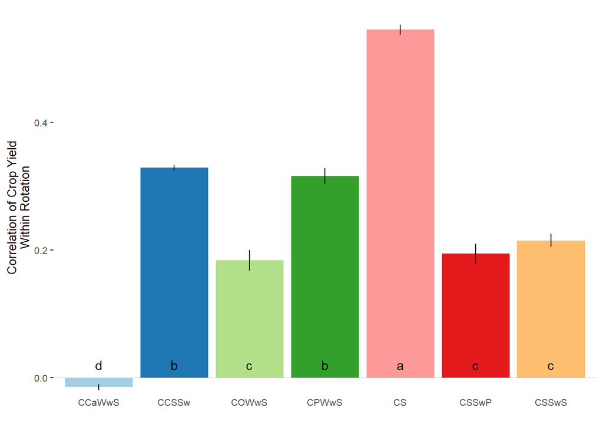

```r
se_hi = function(x) mean(x) + sd(x)/sqrt(length(x))
se_lo = function(x) mean(x) - sd(x)/sqrt(length(x))

ggplot(tt,
       aes(x=ROTATION,
           y=YIELD_COR,
           fill=ROTATION)) +
  scale_fill_brewer(palette='Paired') +
  geom_hline(aes(yintercept=0),
             color='gray',
             size=0.2) +
  stat_summary(fun=mean,
               geom='col') +
  stat_summary(fun.max=se_hi,
               fun.min=se_lo,
               geom='errorbar',
               # position=position_dodge(width=0.8),
               width=0) +
  geom_text(data=grp,
            aes(x=ROTATION,
                y=0.02,
                label=trimws(.group)),
            inherit.aes=FALSE) +
  labs(x=NULL,
       y='Correlation of Crop Yield\nWithin Rotation') +
  guides(fill='none') +
  theme(panel.background=element_blank(),
        axis.ticks.x=element_blank(),
        axis.text.x=element_text(vjust=10),
        text=element_text(size=10))
```

## Plot: Among individual crops

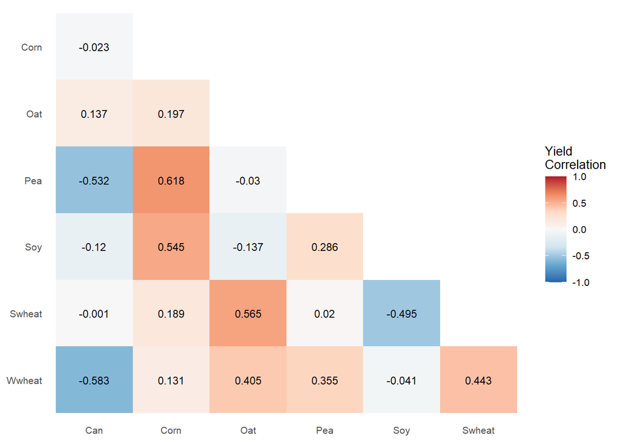

```r
tt = aggregate(YIELD ~ YEAR + CURRENT + REP, data=df, mean) %>%
  pivot_wider(id_cols=c('REP', 'YEAR'),
              names_from='CURRENT',
              values_from='YIELD') %>%
  split(., .$REP) %>%
  lapply(function(x) {
    out = cor(x[, -c(1,2)], use='complete.obs')
    out[!upper.tri(out)] = NA
    out %<>%
      data.frame(
        CROP1 = rownames(.),
        .
      ) %>% pivot_longer(cols=where('is.numeric'),
                          names_to='CROP2') %>%
      na.omit %>%
      as.data.frame
    out
  }) %>%
  do.call(rbind, .)
tt$REP = rownames(tt) %>%
  strsplit('\\.') %>%
  sapply('[', 1)

tt_mean = aggregate(value ~ CROP1 + CROP2, data=tt, mean)


ggplot(tt_mean,
       aes(x=CROP1,
           y=CROP2,
           fill=value)) +
  scale_y_discrete(limits=rev) +
  scale_fill_distiller(limits=c(-1, 1),
                       na.value='white',
                       palette='RdBu') +
  geom_tile() +
  geom_text(aes(label=ifelse(is.na(value), '', round(value, 3))),
            size=3) +
  labs(x=NULL,
       y=NULL,
       fill='Yield\nCorrelation') +
  theme(panel.background=element_blank(),
        axis.ticks=element_blank(),
        text=element_text(size=10))
```

Can probably clean this up, but clearly the strongest positive correlations are among corn, soy, and pea; and among the small grains. The small grains and warm season crops are not correlated strongly.

## Clusters of weather response groups

```r
clust = aggregate(YIELD ~ YEAR + CURRENT, data=df, mean) %>%
  pivot_wider(id_cols='YEAR',
              names_from=c('CURRENT'),
              values_from='YIELD') %>%
  as.data.frame %>%
  set_rownames(., .$YEAR) %>%
  .[, -c(1)] %>%
  as.matrix %>%
  apply(2, scale) %>%
  t
```

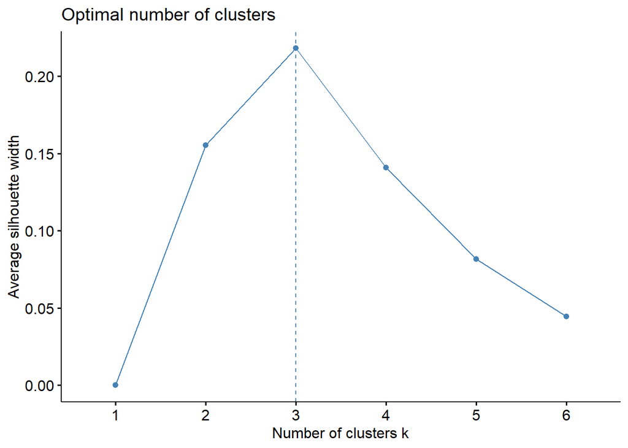

```r
tt = fviz_nbclust(clust,
             FUN=hcut,
             method='silhouette',
             hc_method='complete',
             hc_metric='pearson',
             k.max=nrow(clust)-1)
tt
```

```r
.calc_silhouette = function(k, x, d) {
  require(cluster)
  hcut(x, k) %>%
    .[['cluster']] %>%
    silhouette(d) %>%
    .[, 'sil_width'] %>%
    mean
}

calc_silhouette = function(x, max_k=nrow(x)-1) {
  d = dist(x)
  all_k = seq(2, max_k, by=1)
  sils = sapply(all_k, .calc_silhouette, x, d) %>%
    c(0, .)
  # names(sils) = c(1, all_k)
  return(sils)
}

best_k = calc_silhouette(clust) %>%
  which.max()
```

3 clusters it is.

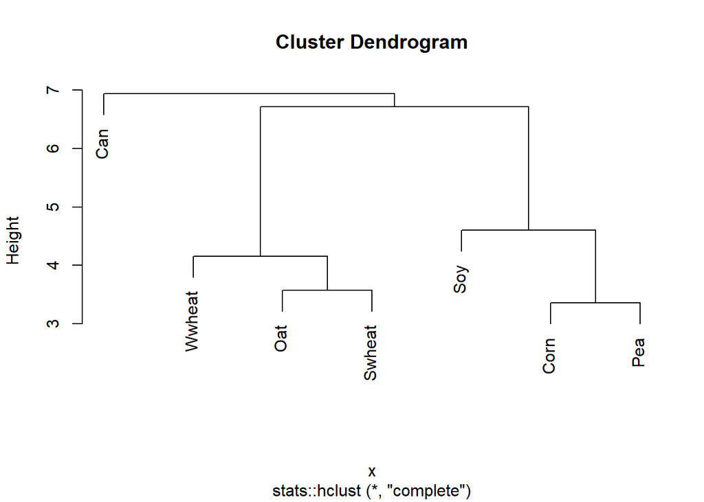

```r
clusters =
  hcut(clust,
       k=best_k,
       hc_method='complete',
       hc_metric='euclidean',
       graph=TRUE)
plot(clusters)
```

```r
clusters$cluster %>%
  sort %>%
  cbind(cluster=.)
```

```
##        cluster
## Can          1
## Corn         2
## Pea          2
## Soy          2
## Oat          3
## Swheat       3
## Wwheat       3
```

These clusters are arbitrarily named, so no problem re-label to make the writing a bit clearer.

```r
clusters_reid = c(3,2,1)
clusters$cluster %<>%
  clusters_reid[.] %>%
  set_names(names(clusters$cluster))

clusters$cluster %>%
  sort %>%
  cbind(cluster=.)
```

```
##        cluster
## Oat          1
## Swheat       1
## Wwheat       1
## Corn         2
## Pea          2
## Soy          2
## Can          3
```

## Weather response and yield stability

```r
weather_diversity = function(rotation, clusters, key, index=c('richness', 'inverse_simpson', 'gini_simpson')) {
  index = match.arg(index)

  # get rotation information
  rotation_crops = key[[rotation]]
  rotation_length = length(rotation_crops)

  # reassign crops as as weather groups
  crop_clusters = clusters$cluster
  crop_groups = crop_clusters[rotation_crops]

  if (index=='richness') {
    out = unique(crop_groups) %>%
      length

  } else if (index=='inverse_simpson') {

    # Pr(each group occurrence)
    out = tapply(crop_groups, crop_groups, length) %>%
      divide_by(rotation_length)
    # sum square and
    out = 1/sum(out^2)
  } else if (index=='gini_simpson') {
    out = tapply(crop_groups, crop_groups, length) %>%
      divide_by(rotation_length)
    out = 1-(sum(out^2))
  }

  return(out)
}

ei$WEATHERDIV = sapply(ei$ROTATION, weather_diversity, clusters, rotations, 'inverse_simpson')
ei %<>% merge(unique(rot[, c('ROTATION', 'CROP_DIV')]))
```

## stability vs weather or diversity

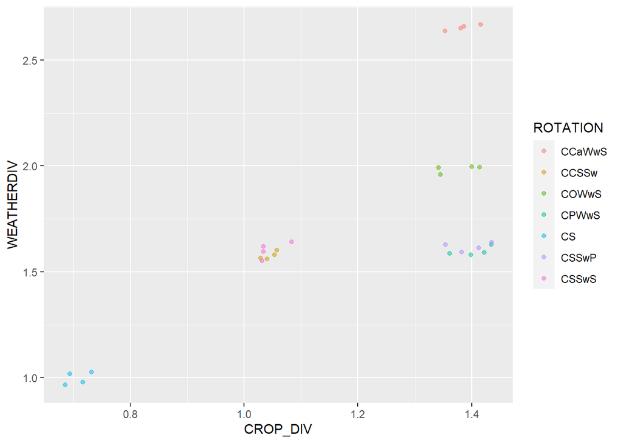

```r
ggplot(ei, aes(x=CROP_DIV, y=WEATHERDIV, color=ROTATION)) +
  geom_point(position=position_jitter(width=0.05,
                                      height=0.05),
             alpha=0.5)
```

```r
cor(ei[, c('SLOPE', 'WEATHERDIV', 'CROP_DIV')])
```

```
##                 SLOPE WEATHERDIV   CROP_DIV
## SLOPE       1.0000000 -0.8212751 -0.6656866
## WEATHERDIV -0.8212751  1.0000000  0.7064160
## CROP_DIV   -0.6656866  0.7064160  1.0000000
```

```r
wetgrp_mod = lmer(SLOPE ~ WEATHERDIV + CROP_DIV + (1|REP), data=ei)
```

```
## boundary (singular) fit: see help('isSingular')
```

```r
Anova(wetgrp_mod, test.statistic='F')
```

|  | F | Df | Df.res | Pr(>F) |
| --- | --- | --- | --- | --- |
| WEATHERDIV | 19.777195 | 1 | 22 | 0.0002023772 |
| CROP_DIV | 1.174023 | 1 | 22 | 0.2903087563 |

Crop diversity doesn’t matter as much as weather diversity.

```r
mm = lm(SLOPE ~ WEATHERDIV, data=ei)
rsq = mm %>%
  summary %>%
  .$r.squared %>%
  round(3) %>%
  paste0('italic(r)^2==', .)
p_val = mm %>%
  Anova(test.statistic='F') %>%
  .[1, 4]
p_val = ifelse(p_val < 0.001,
               'italic(p)<0.001',
               paste0('italic(p)==', round(p_val, 3)))
```

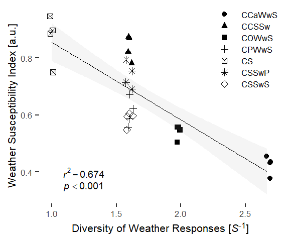

```r
plt_stability_weather =
  ggplot(ei,
         aes(x=WEATHERDIV,
             y=SLOPE,
             shape=ROTATION)) +
  scale_shape_manual(values=shape_scale) +
  geom_point(position=position_jitter(width=0.03, height=0)) +
  geom_smooth(aes(shape=NULL),
              method='lm',
              formula='y~x',
              color='black',
              size=0.1,
              alpha=0.1) +
  annotate(geom='text',
           x=1.25,
           y=0.400,
           label=rsq,
           size=2.5,
           parse=TRUE) +
    annotate(geom='text',
           x=1.25,
           y=0.350,
           label=p_val,
           size=2.5,
           parse=TRUE) +
  labs(x='Diversity of Weather Responses [*S*<sup>-1</sup>]',
       y='Weather Susceptibility Index [a.u.]',
       shape=NULL) +
  # guides(shape=guide_legend(ncol=2)) +
  theme(panel.background=element_blank(),
        legend.key=element_blank(),
        legend.position=c(0.85, 0.8),
        legend.key.height=unit(0.12, 'in'),
        axis.title.x=element_markdown(),
        text=element_text(size=8))
plt_stability_weather
```

# Weather Dependency of Individual Crops

This will be via redundancy analysis. Weather patterns will be used to separate different years, and crop yields will the be projected onto those weather patterns.

We can follow up using linear models for individual crops.

## RDA

1. Average crop yields within crop-rep-year. Since corn and soybean are so common we don’t want them to dominate the variance of all species observed.
2. Transform to a table of year ~ crop-rep. Scale within crop-rep.
3. RDA yields ~ weather

We can get an R-squared and p-value from this but strictly speaking it’s a test of whether years had different weather patterns, not whether crops respond to different weather patterns.

Here are the transformed crop yields (columns are scaled). We’ll use imputed yields (mostly canola) because otherwise we need to drop entire years of data.

```r
crop_yields = aggregate(YIELD ~ YEAR + CURRENT + REP, data=df, mean) %>%
  pivot_wider(values_from='YIELD', names_from='YEAR') %>%
  as.data.frame


Y = crop_yields
Y[, c('CURRENT', 'REP')] = NULL

cn = with(crop_yields,
          paste(CURRENT,
                REP,
                sep='_'))
rn = colnames(Y)

Y %<>%
  as.matrix %>%
  apply(1, scale) %>%
  set_colnames(cn) %>%
  set_rownames(rn)

corner(Y)
```

```
##            Can_1     Corn_1       Oat_1       Pea_1      Soy_1   Swheat_1
## 2001 -0.73750477 -1.3024428 -0.03628768 -0.14623820 -2.8852462  1.5591274
## 2002  1.61865447 -1.4752154  0.29134617 -1.97929070 -0.6521093 -0.8893269
## 2003  1.19806236  0.3494048 -0.08309251  0.02016731 -0.6008195  1.5998350
## 2004  1.50936255  0.5284360  2.54800787 -1.01040633 -0.6922270  1.8350820
## 2005  0.02274534  2.1769938  0.38718464  1.84883879  0.6666983 -0.1535908
## 2006 -0.35420319 -0.4418876 -1.16740453  0.01187295  1.0363910 -1.1961336
```

Line up weather (avoiding avg_maxt)

```r
drop = colnames(wet) %>%
  grepl('AVG_MAXT', .)
X = wet[, !drop]
rownames(X) = X$YEAR
X$YEAR = NULL
X = X[rownames(Y), ] %>%
  lapply(scale) %>%
  data.frame
head(X)
```

|  | MarApr_PRECIP | AprMay_PRECIP | MayJun_PRECIP | JunJul_PRECIP | JulAug_PRECIP | AugSep_PRECIP | MarApr_MEANT | AprMay_MEANT | MayJun_MEANT | JunJul_MEANT | JulAug_MEANT | AugSep_MEANT |
| --- | --- | --- | --- | --- | --- | --- | --- | --- | --- | --- | --- | --- |
| 1 | -0.2102754 | -1.6942120 | -0.7331411 | -0.8537381 | -0.4953468 | -0.65330518 | -0.8947993 | 1.3807496 | -0.7120865 | 0.12321711 | 1.3226133 | 0.6151829 |
| 2 | -1.1008536 | -1.7982711 | -1.1698190 | -0.6470844 | 0.4666423 | -0.47557724 | -1.0943105 | -0.8212427 | -0.1578190 | 1.97123267 | 0.4229710 | 1.0550193 |
| 3 | -1.1750684 | 1.3829638 | -1.2680715 | -0.1221840 | -0.2222660 | 0.01627451 | 0.7735493 | -0.1375723 | -1.2240325 | -0.17144299 | -0.3729742 | 0.8847601 |
| 4 | -0.3587051 | -0.4826669 | 1.9033012 | 0.6920315 | -1.2401127 | -0.67397122 | 0.2580540 | 0.5019700 | -1.0177152 | -2.19403622 | -1.5136422 | -0.3565892 |
| 5 | 1.1874376 | -0.3117127 | 1.0244871 | -0.3081723 | -1.0725404 | 1.70675657 | 0.7372201 | -0.5388228 | 0.2473614 | 0.91412147 | -0.1225397 | 0.3951402 |
| 6 | 1.4224512 | 0.5504911 | -1.4536595 | -0.8909357 | 0.7583423 | 1.90515055 | 0.4236313 | -0.1062098 | 1.6240129 | -0.09018239 | 0.7893140 | -0.9368148 |

Ordinate.

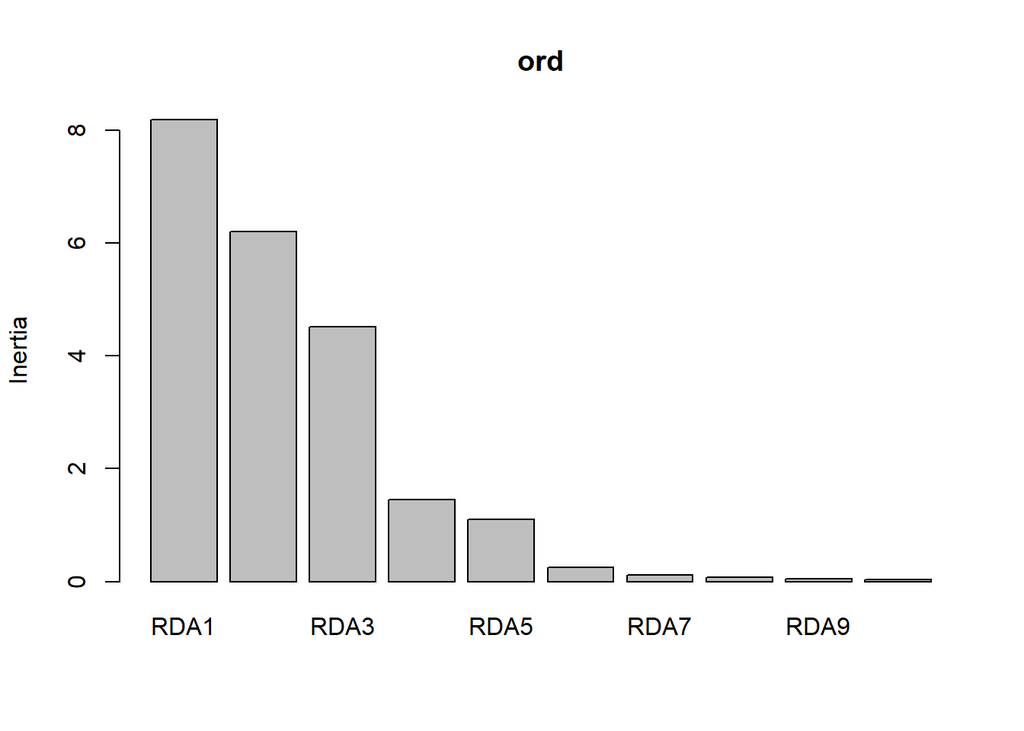

```r
ff = paste(colnames(X), collapse='+') %>%
  paste('Y ~', .) %>%
  formula
ord = rda(ff, data=X)
screeplot(ord)
```

3 useful axes.

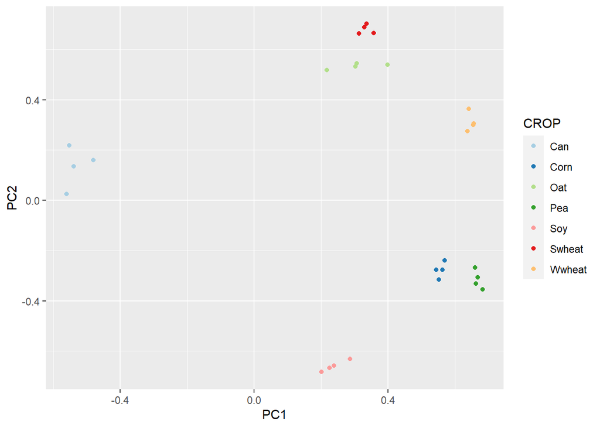

```r
tt = rda(Y)
tt_scores = scores(tt, display='species') %>%
  as.data.frame
tt_scores$CROP = strsplit(rownames(tt_scores), '_')  %>%
  do.call(rbind, .) %>%
  .[, 1]
ggplot(tt_scores,
       aes(x=PC1,
           y=PC2,
           color=CROP)) +
  geom_point() +
  scale_color_brewer(palette='Paired')
```

### Plot

(plotting function)

```r
plot_ord = function(ordination, axes=c(1,2), lab_color='Weather', lab_fill='Crop') {

  # select axes and infer information about them
  axnames = paste0("RDA", axes)
  xax = axnames[1]
  yax = axnames[2]
  variances = summary(ordination)$cont$importance[2, axes]*100

  # generate scores for columns
  cropscores = scores(ordination, display='sp', choices=axes) %>%
    as.data.frame
  cropscores[c('CURRENT', 'REP')] = strsplit(rownames(cropscores), '_') %>%
    do.call(rbind, .)
  cropscores

  # generate scores for predictors
  weatherscores = scores(ordination, display='bp', choices=axes) %>%
    as.data.frame
  weatherscores$zero = 0
  weatherscores$label = rownames(weatherscores)
  weatherscores$color = grepl('PRECIP', weatherscores$label) %>%
    sapply(ifelse, 'Precipitation', 'Temperature')

  # create labels for predictors
  weathertext = weatherscores
  weathertext[c(xax, yax)] %<>% lapply('*', 1.1)

  # Plot
  ggplot(cropscores,
         aes_string(x=xax,
                    y=yax,
                    fill='CURRENT')) +
    coord_equal() +
    # scale_x_continuous(limits=c(-0.7, 0.7),
    #                    breaks=seq.int(-6, 6, by=2)/10) +
    # scale_shape_manual(values=c(15:18, 7, 8, 11)) +
    scale_fill_brewer(palette='Paired') +
    scale_color_manual(values=c('steelblue4', 'tomato4')) +
    geom_hline(aes(yintercept=0),
               color='lightgray') +
    geom_vline(aes(xintercept=0),
               color='lightgray') +
    geom_point(size=4,
               alpha=1,
               shape=21,
               color='darkgray') +
    geom_segment(data=weatherscores,
                 aes(x=zero,
                     y=zero,
                     xend=.data[[xax]],
                     yend=.data[[yax]],
                     color=color),
                 arrow=arrow(length=unit(0.05, 'inches')),
                 alpha=0.5,
                 inherit.aes=FALSE) +
    geom_text(data=weathertext,
              aes_string(x=xax,
                         y=yax,
                         label='label',
                         color='color'),
              size=4,
              alpha=0.7,
              inherit.aes=FALSE) +
    labs(x=paste(xax, ' [', signif(variances[1], 2), '%]', sep=''),
         y=paste(yax, ' [', signif(variances[2], 2), '%]', sep=''),
         color=lab_color,
         fill=lab_fill) +
    theme_minimal() +
    theme(panel.grid=element_blank())
}
```

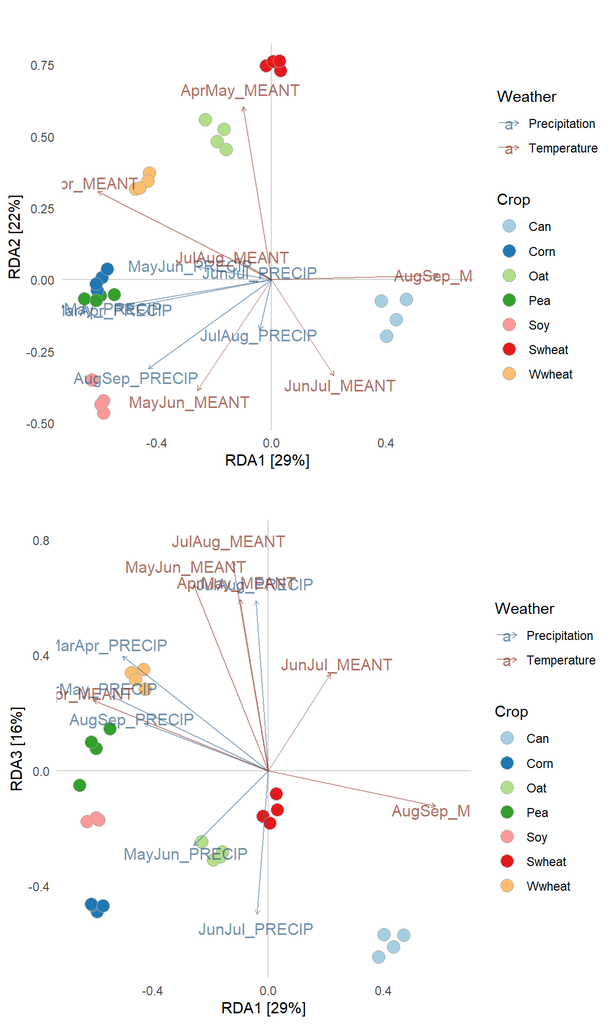

```r
grid.arrange(plot_ord(ord), plot_ord(ord, axes=c(1,3)), nrow=2)
```

### Plot for export

```r
plot_export_ord = function(ordination, axes=c(1,2), lab_color='Weather', lab_shape='Crop') {

  # select axes and infer information about them
  axnames = paste0("RDA", axes)
  xax = axnames[1]
  yax = axnames[2]
  variances = summary(ordination)$cont$importance[2, axes]*100

  # generate scores for columns
  cropscores = scores(ordination, display='sp', choices=axes) %>%
    as.data.frame
  cropscores[c('CURRENT', 'REP')] = strsplit(rownames(cropscores), '_') %>%
    do.call(rbind, .)
  cropscores$CLUSTER = clusters$cluster[cropscores$CURRENT] %>%
    factor

  hull = split(cropscores, cropscores$CURRENT) %>%
    lapply(function(x) {
      tt = x[, c('CURRENT', xax, yax)] %>%
        .[chull(.[, c(2, 3)]), ]
    }) %>%
    do.call(rbind, .)
  hull$CLUSTER = clusters$cluster[hull$CURRENT] %>%
    factor


  prettycrops = c(
    Corn = 'Corn',
    Soy = 'Soybean',
    Pea = 'Pea',
    Wwheat = 'WinWheat',
    Swheat = 'SprWheat',
    Oat = 'Oats',
    Can = 'Canola'
  )
  centers = sapply(c(xax, yax),
                 function(x) tapply(cropscores[, x], cropscores$CURRENT, mean)) %>%
  as.data.frame
  centers$CURRENT = prettycrops[rownames(centers)]

  # generate scores for predictors
  weatherscores = scores(ordination, display='bp', choices=axes) %>%
    as.data.frame
  weatherscores$zero = 0
  weatherscores$label = rownames(weatherscores)
  weatherscores$color = grepl('PRECIP', weatherscores$label) %>%
    sapply(ifelse, 'Precipitation', 'Temperature')

  # create labels for predictors
  weathertext = weatherscores
  weathertext[c(xax, yax)] %<>% lapply('*', 1.1)
  weathertext$label_short = strsplit(weathertext$label, '_') %>% sapply('[', 1)

  # Plot
  ggplot(cropscores,
         aes_string(x=xax,
                    y=yax)) +
    coord_equal(clip='off') +
    # scale_x_continuous(limits=c(-0.7, 0.7),
    #                    breaks=seq.int(-6, 6, by=2)/10) +
    # scale_shape_manual(values=c(15:18, 7, 8, 11)) +
    scale_fill_manual(values=palette_3) +#wes_palette('Darjeeling1', best_k)) +
    scale_color_manual(values=c('steelblue4', 'tomato4')) +
    scale_shape_manual(values=rep(20, 7)) +
    geom_hline(aes(yintercept=0),
               color='lightgray',
               size=0.1) +
    geom_vline(aes(xintercept=0),
               color='lightgray',
               size=0.1) +
    geom_point(aes(fill=CLUSTER),
               size=3,
               shape=21,
               color='darkgray',
               alpha=0.5) +
    geom_segment(data=weatherscores,
                 aes(x=zero,
                     y=zero,
                     xend=.data[[xax]],
                     yend=.data[[yax]],
                     color=color),
                 arrow=arrow(length=unit(0.03, 'inches')),
                 alpha=0.5,
                 inherit.aes=FALSE,
                 size=0.1) +
    geom_text(data=weathertext,
              aes_string(x=xax,
                         y=yax,
                         label='label_short',
                         color='color'),
              size=2,
              alpha=0.7,
              inherit.aes=FALSE) +
    # geom_polygon(data=hull,
    #              aes(shape=CURRENT,
    #                  fill=CLUSTER),
    #              linewidth=0.2,
    #              # fill='darkgray',
    #              alpha=0.5) +
    geom_text(data=centers,
              aes_string(x=xax,
                         y=yax,
                         label='CURRENT'),
              color='black',
              size=2.5) +
    labs(x=paste(xax, ' [', signif(variances[1], 2), '%]', sep=''),
         y=paste(yax, ' [', signif(variances[2], 2), '%]', sep=''),
         color=' ',
         fill='Weather\nResponse Group') +
    guides(fill=guide_legend(title.position='top',
                             label.position='bottom',
                             direction='horizontal'),
           color=guide_legend(direction='vertical')) +
    theme(panel.background=element_blank(),
          text=element_text(size=8),
          legend.key.height=unit(0.12, 'in'),
          legend.key=element_blank(),
          legend.margin=margin(t=-5, b=-5),
          legend.position='bottom')
}

plt_crop_weather = plot_export_ord(ord)
```

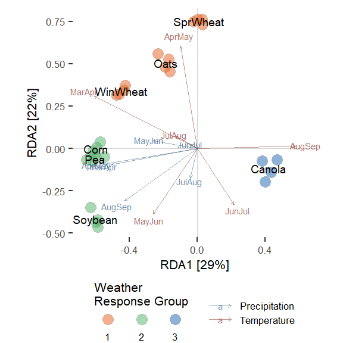

```r
plt_crop_weather
```

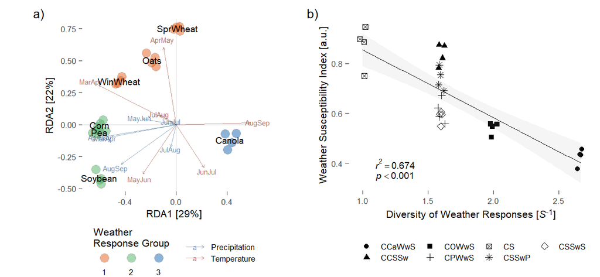

```r
p1 = plt_crop_weather +
  labs(tag='a)') +
  theme(axis.ticks=element_line(linewidth=0.1))
p2 = plt_stability_weather +
  labs(tag='b)') +
  theme(legend.position='bottom',
        legend.key.width=unit(0.2, 'in'),
        legend.justification='right',
        axis.ticks=element_line(linewidth=0.1))
grid.arrange(p1, p2, nrow=1)
```

### Export

```r
here(out_dir, 'Figure 5 - Weather and Stability.jpg') %>%
  jpeg(width=6.5, height=3, units='in', res=300)
grid.arrange(p1, p2, nrow=1)
dev.off()
```

## Individual crops

Don’t use imputed data in this case.

```r
crop_predictors = list(
  Warm = c('AprMay', 'MayJun', 'JunJul', 'JulAug', 'AugSep'),
  Cool = c('MarApr', 'AprMay', 'MayJun', 'JunJul', 'JulAug')
)
crop_predictors[c('Oat', 'Pea', 'Can', 'Wwheat', 'Swheat')] =
  lapply(1:5, function(x) crop_predictors[['Cool']])
crop_predictors[c('Corn', 'Soy')] =
  lapply(1:2, function(x) crop_predictors[['Warm']])

crop_predictors %<>% lapply(function(x) {
  c(paste0(x, '_PRECIP'),
    paste0(x, '_MEANT'))
})


get_predictors = function(x, data_list, predictors) {
  tt = data_list[[x]]
  message(x)

  drop = !grepl(x, colnames(predictors)) & grepl('FLOWER', colnames(predictors))
  X = predictors[, !drop] %>%
    set_rownames(., .[, 'YEAR'])
  X[, 'YEAR'] = NULL
  X %<>% as.matrix
  # expand to match replicates
  X = X[as.character(tt$YEAR), , drop=FALSE]
  # check to ensure just keeping relevant weather, including flowering temp
  keep_predictors = colnames(X) %in% crop_predictors[[x]]
  X = X[, keep_predictors, drop=FALSE] %>%
    scale
  # keep = sapply(weather_months[[x]], function(y) {
  #   grepl(y, colnames(X))
  # }) %>%
  #   apply(1, any)
  # X = X[, keep]
  # X %<>% scale

  # remove plot, and rep effects
  partial = paste('YIELD ~', error_structure) %>%
    formula %>%
    lmer(data=tt) %>%
    residuals %>%
    matrix %>%
    scale

  # identify predictors using lasso
  # mod = glmnet(X, partial, alpha=1, intercept=FALSE)
  cv_mod = cv.glmnet(X, partial, alpha=.9, intercept=FALSE)
  mat = coef(cv_mod, s='lambda.1se')
  # is_kept = mat[, 1] != 0
  # out = rownames(mat)[is_kept]
  # out = out[-c(1)]
  out = mat
  return(out)
}

test_predictors = function(x, data_list, predictors, lasso) {


  dd = data_list[[x]] %>%
    merge(predictors, by='YEAR')

  keep = lasso[[x]] %>%
    .[,1] !=0
  mod = names(keep)[keep] %>%
    paste(collapse='+') %>%
    paste('YIELD ~', .) %>%
    formula %>%
    lm(data=dd)

  return(mod)
}

process_test = function(x, alpha=0.05) {

  levels = data.frame(
    p_val = c(1, 0.1, 0.05, 0.01, 0.001),
    symbol = c('', '.', '*', '**', '***')
  )

  .set_symbol = function(value, levels) {
    test = {value < levels$p_val} %>%
      which %>%
      max
    return(levels[test, 'symbol'])
  }

  test = Anova(x)
  test = data.frame(
    PRED = rownames(test),
    SYMBOL = sapply(test[, 4], .set_symbol, levels)
  ) %>%
    na.omit
  return(test)
}

process_predictors = function(name, preds) {
  x = preds[[name]]
  out = data.frame(
    PRED = slot(x, 'Dimnames')[[1]],
    CROP = name,
    COEF = matrix(x))
  return(out)
}
```

```r
error_structure = '(1|REP)'
# cycle = variety effects
# rep = block effects
# rep*cycle_year = plot effects


subdf = subset(df, !IMPUTED) %>%
  aggregate(YIELD ~ CURRENT + REP + CYCLE + CYCLE_YEAR + YEAR,
            data=.,
            mean) %>%
  split(., .$CURRENT)


crp = names(subdf) %>%
  set_names(names(subdf))
preds = lapply(crp, get_predictors, subdf, wet)
```

```
## Can
```

```
## boundary (singular) fit: see help('isSingular')
```

```
## Corn
```

```
## boundary (singular) fit: see help('isSingular')
```

```
## Oat
```

```
## boundary (singular) fit: see help('isSingular')
```

```
## Pea
```

```
## boundary (singular) fit: see help('isSingular')
```

```
## Soy
```

```
## boundary (singular) fit: see help('isSingular')
```

```
## Swheat
```

```
## boundary (singular) fit: see help('isSingular')
```

```
## Wwheat
```

```
## boundary (singular) fit: see help('isSingular')
```

```r
pred_test = lapply(crp, test_predictors, subdf, wet, preds) %>%
  lapply(process_test) %>%
  do.call(rbind, .) %>%
  data.frame(CROP = strsplit(rownames(.), '\\.') %>% sapply('[', 1),
             .) %>%
  set_rownames(NULL)
preds = lapply(crp, process_predictors, preds) %>%
  do.call(rbind, .) %>%
  set_rownames(NULL) %>%
  merge(pred_test, by=c('PRED', 'CROP'))


preds %<>% subset(PRED != '(Intercept)')
preds$PRED[grepl('FLOWER', preds$PRED)] %<>%
  strsplit('_') %>%
  lapply('[', -c(1)) %>%
  sapply(paste, collapse='_')

# test = lapply(crp, test_predictors, subdf, preds)
# lapply(test, Anova)
```

```r
preds %<>% pivot_wider(id_cols='CROP', names_from='PRED', values_from='COEF')
preds[is.na(preds)] = 0
preds %<>% pivot_longer(cols=where('is.numeric'),
                        names_to='PRED',
                        values_to='COEF') %>%
  merge(pred_test, by=c('CROP', 'PRED'))
```

### Plot

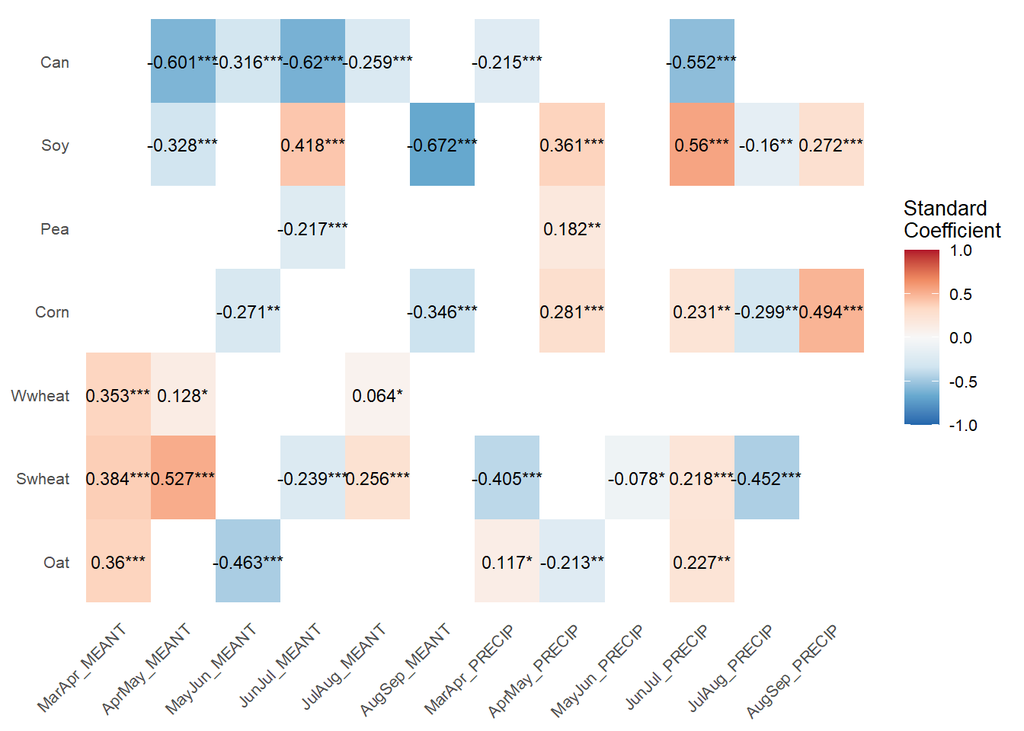

```r
fact_lvl = unique(preds$PRED)
is_precip = grepl('PRECIP', fact_lvl)
preds$PRED %<>% factor(., levels=c(fact_lvl[!is_precip], fact_lvl[is_precip]))
preds$LABEL = with(preds, paste0(round(COEF, 3), SYMBOL))

lvls = c(
  'MarApr_',
  'AprMay_',
  'MayJun_',
  'JunJul_',
  'JulAug_',
  'AugSep_') %>%
  rep(2) %>%
  paste0(c(rep('MEANT', 6), rep('PRECIP', 6)))

keep = grepl('\\*', preds$SYMBOL)
preds$PRED %<>% factor(levels=lvls)
preds$CROP %<>% factor(levels=clusters$cluster %>% sort %>% names)

ggplot(preds[keep, ],
       aes(y=CROP,
           x=PRED,
           fill=COEF)) +
  geom_tile() +
  scale_fill_distiller(limits=c(-1, 1), palette='RdBu') +
  geom_text(aes(label=LABEL),
            size=3) +
  labs(x=NULL,
       y=NULL,
       fill='Standard\nCoefficient') +
  theme(panel.background=element_blank(),
        axis.text.x=element_text(angle=45, hjust=1, vjust=1),
        axis.ticks=element_blank(),
        text=element_text(size=10))
```

This confirms what was obvious from the RDA. Small grains like warm establishment Soy and corn like rainfall, though hot summers are also bad.

### Combine with clusters

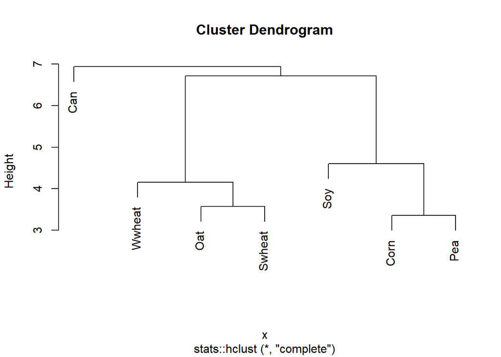

```r
plot(clusters)
```

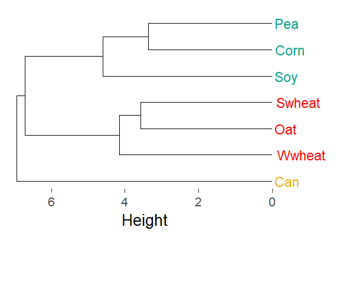

```r
plt_clust_data = as.dendrogram(clusters) %>%
  dendro_data(type='rectangle')
leaves = label(plt_clust_data)
leaves$group = clusters$cluster[leaves$label] %>%
  factor
plt_clusters =
  ggplot(segment(plt_clust_data)) +
  scale_color_manual(values=wes_palette('Darjeeling1', 3),
                     guide='none') +
  geom_segment(aes(x=x,
                   y=y,
                   xend=xend,
                   yend=yend),
               linewidth=0.1) +
  geom_text(data=leaves,
            aes(x=x,
                y=y,
                label=label,
                color=group),
            hjust=-0.1,
            size=3) +
  coord_flip(clip='off') +
  scale_y_reverse() +
  labs(y='Height',
       x=NULL) +
  theme(panel.background=element_blank(),
        axis.ticks.y=element_blank(),
        axis.text.y=element_blank(),
        axis.ticks.x=element_line(linewidth=0.1),
        text=element_text(size=10),
        plot.margin=margin(t=10, b=35, r=35))

plt_clusters
```

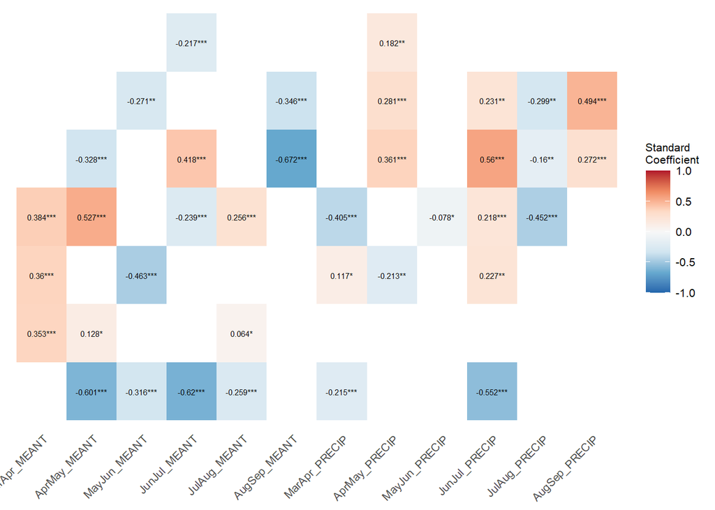

```r
y_order = leaves$label[order(leaves$x)]
preds$CROP %<>% factor(levels=y_order)
plt_weathereff =
  ggplot(preds[keep, ],
         aes(y=CROP,
             x=PRED,
             fill=COEF)) +
  geom_tile() +
  scale_fill_distiller(limits=c(-1, 1), palette='RdBu') +
  geom_text(aes(label=LABEL),
            size=2) +
  labs(x=NULL,
       y=NULL,
       fill='Standard\nCoefficient') +
  theme(panel.background=element_blank(),
        axis.text.x=element_text(angle=45, hjust=1, vjust=1),
        axis.ticks=element_blank(),
        text=element_text(size=10),
        legend.title=element_text(size=8),
        axis.text.y=element_blank())

plt_weathereff
```

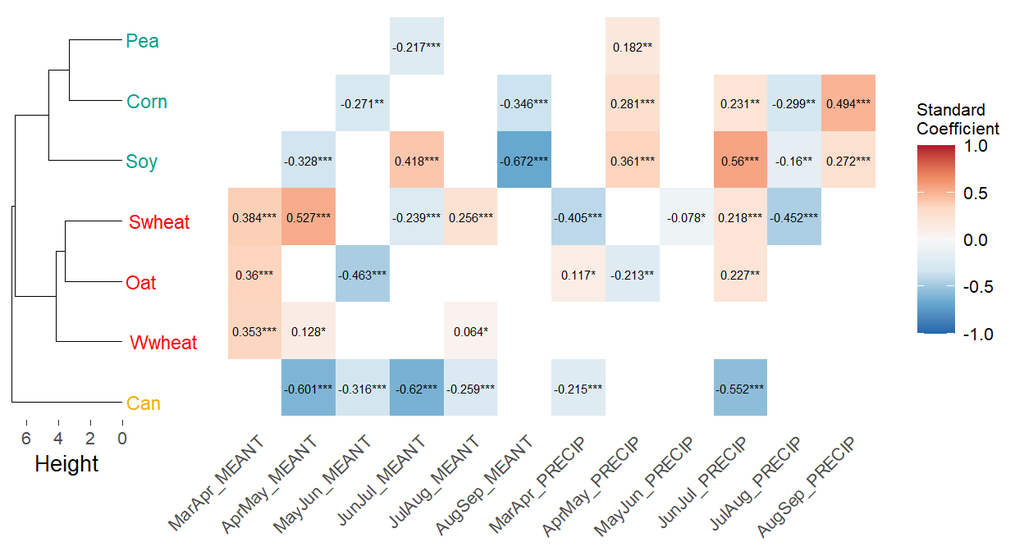

```r
marrangeGrob(grobs=list(plt_clusters, plt_weathereff),
             layout_matrix=matrix(c(1,2,2,2,2), nrow=1),
             nrow=1, ncol=2, top=NULL)
```

```r
here(out_dir,
     'SUPPL FIGURE - Weather Dependence of Crops and Clusters.jpg') %>%
  jpeg(height=3.5, width=6.5, units='in', res=300)
marrangeGrob(grobs=list(plt_clusters, plt_weathereff),
             layout_matrix=matrix(c(1,2,2,2,2), nrow=1),
             nrow=1, ncol=2, top=NULL)
```

```r
dev.off()
```